# DATA101 Final Project

Mohamed Nabeel

12/17/2019

```r
library(reshape2)
library(zoo)
library(readr)
library(tidyr)
library(dplyr)
library(tidyverse)
```

```r
library(ggplot2)
library(scales)
library(RColorBrewer)
library(plotly)
library(ggthemes)
library(highcharter)
df<-read.csv("Arrests.csv")
```

#1

The dataset used shows the color, year, age, sex, employment status, citizenship, checks and release status for people arrested for Marijuana possession.

#2

```r
sum(is.na(df))
```

```
## [1] 0
```

```r
mean(is.na(df))
```

```
## [1] 0
```

#3

Question 1: What type of variation occurs in the sex of people getting arrested?

Question 2: What type of variation occurs in the age of people getting arrested?

#4

```r
table(df$sex)
```

```
##
## Female   Male
##    443   4783
```

```r
fivenum(df$age)
```

```
## [1] 12 18 21 27 66
```

```r
df<-rename(df,Arrests=X)
```

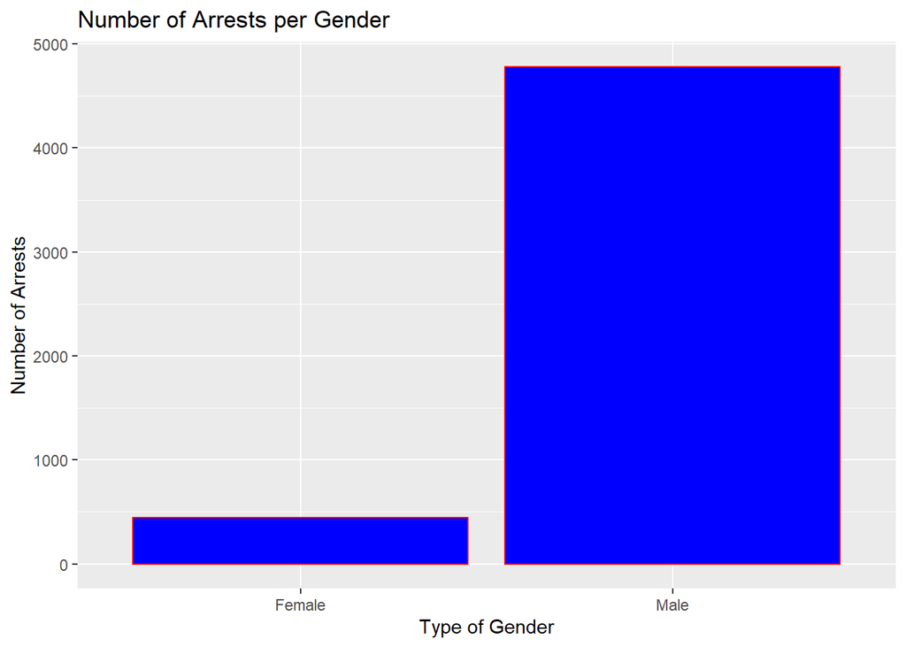

```r
ggplot(df) +
  xlab("Type of Gender") +
  ylab("Number of Arrests") +
  ggtitle("Number of Arrests per Gender") +
  geom_bar(aes(x=sex),color="red",fill="blue",)
```

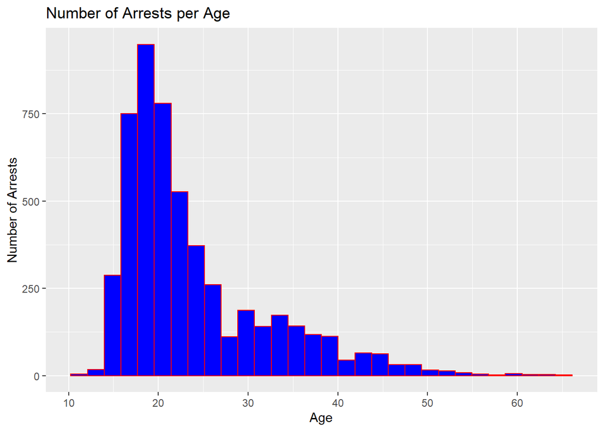

```r
ggplot(df) +
  xlab("Age") +
  ylab("Number of Arrests") +
  ggtitle("Number of Arrests per Age") +
  geom_histogram(aes(x=age),color="red",fill="blue",)
```

#5

Looking at the bar plot for the number of Arrests for each gender group, it is clear to see that most of the Arrests came from males. The amount of males arrested was 4,783, which accounted for 91.5% of the total arrests, while the females only accounted for 8.5% of the total arrests.

Looking at the number of Arrests for each age group, it is clear to see that most of the arrests occured with people between the ages of 18-27. The histogram for this variable is skewed right, meaning that most of the data is towards the left of the plot, because older people had a lower chance of getting arrested.

#6

Is the mean of the amount of black people getting arrested greater than that of white people getting arrested?

```r
White<-df %>%
  filter(colour == "White")
Black<-df %>%
  filter(colour == "Black")
```

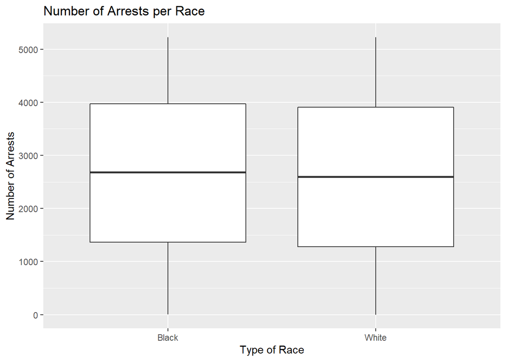

```r
ggplot(data = df) +
  xlab("Type of Race") +
  ylab("Number of Arrests") +
  ggtitle("Number of Arrests per Race") +
  geom_boxplot(mapping = aes(x =colour,y=Arrests))
```

The two t-test assumptions are that a random sample of size n is taken and that the population of the random variable is normally distributed and is large. My dataset meet these assumptions because the the sample was taken at random and the dataset has over 1000 lines of cases of normally distributed data.

Ho:μb=μw Ha:μb>μw

```r
t.test(White$Arrests, Black$Arrests, alternative="less",
       conf.level = 0.95)
```

```
##
##  Welch Two Sample t-test
##
## data:  White$Arrests and Black$Arrests
## t = -0.77037, df = 2211, p-value = 0.2206
## alternative hypothesis: true difference in means is less than 0
## 95 percent confidence interval:
##      -Inf 42.14672
## sample estimates:
## mean of x mean of y
##  2604.357  2641.456
```

#7

Is there a relationship between being a citizen and being employed?

```r
citizen<-as.factor(df$citizen)
employment<-as.factor(df$employed)
citizen_employment_table <- table(citizen, employment)
citizen_employment_table
```

```
##        employment
## citizen   No  Yes
##     No   224  547
##     Yes  891 3564
```

The chi-square test assumptions are that a random sample is taken and the expected frequencies for each cell are greater than or equal to 5. My dataset meets these assumptions because it is a large dataset that represents most of the population and has valid test results.

Ho: Citizenship and employment are independent. Ha: Citizenship and employment are dependent.

```r
result <- chisq.test(citizen_employment_table)
result
```

```
##
##  Pearson's Chi-squared test with Yates' continuity correction
##
## data:  citizen_employment_table
## X-squared = 31.559, df = 1, p-value = 1.935e-08
```

P-value: 1.94 x 10^−8 Conclusion: Reject Ho Real-World Interpretation: There is enough evidence to show that citizenship and employment are related.

#8

What type of covariation occurs between the amount of arrests and the age?

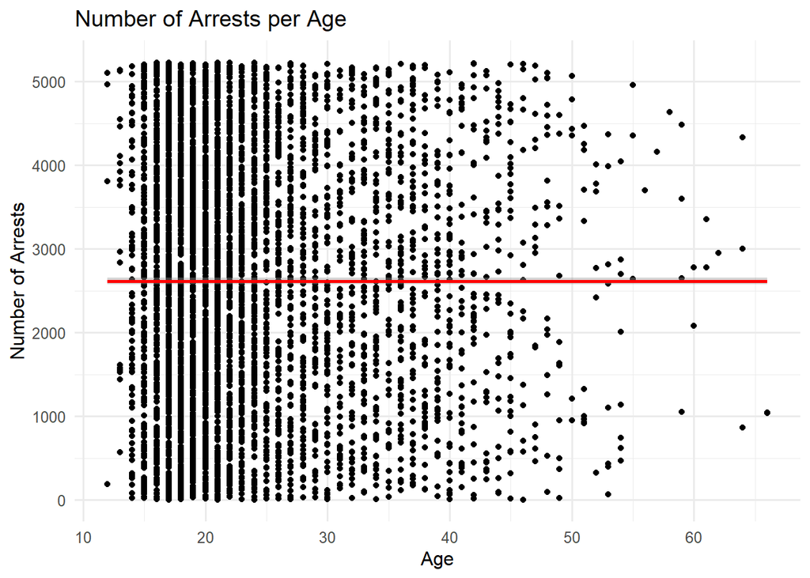

```r
ggplot(df, aes(x = age, y = Arrests)) +
  xlab("Age") +
  ylab("Number of Arrests") +
  theme_minimal(base_size = 12) +
  ggtitle("Number of Arrests per Age")+
  geom_point() + geom_smooth(color = "red")
```

```r
lin_model <- lm(df$Arrests ~ df$age)
lin_model
```

```
##
## Call:
## lm(formula = df$Arrests ~ df$age)
##
## Coefficients:
## (Intercept)       df$age
##   2601.6465       0.4971
```

```r
summary(lin_model)
```

```
##
## Call:
## lm(formula = df$Arrests ~ df$age)
##
## Residuals:
##      Min       1Q   Median       3Q      Max
## -2620.51 -1306.42     2.42  1308.30  2616.40
##
## Coefficients:
##              Estimate Std. Error t value Pr(>|t|)
## (Intercept) 2601.6465    63.3926  41.040   <2e-16 ***
## df$age         0.4971     2.5101   0.198    0.843
## ---
## Signif. codes:  0 '***' 0.001 '**' 0.01 '*' 0.05 '.' 0.1 ' ' 1
##
## Residual standard error: 1509 on 5224 degrees of freedom
## Multiple R-squared:  7.507e-06,  Adjusted R-squared:  -0.0001839
## F-statistic: 0.03922 on 1 and 5224 DF,  p-value: 0.843
```

Our model is not statistically significant (p-value is 0.843). So, we do not have enough evidence to support Ha: there is a correlation and linear relationship between Arrests and age of people getting arrested.

```r
cor(df$Arrests,df$age)
```

```
## [1] 0.002739834
```

#9

One issue with data ethics is rule #3, data hygiene and data relevance. The only two races recorded in this dataset are black and white. There are definately other races being arrested, but there were not accounted for in this dataset. There is also the chance that some people were recognized as black or white when they were actually another race.

Another ethical issue with the data is the ethical challengers in appropriate data collection and use. Are cops targeting a certain race of people? If so, this is a major ethical issue with this dataset.